# Statistical Quality Control with the qcr Package

The R package [*qcr*](https://CRAN.R-project.org/package=qcr) for Statistical Quality Control (SQC) is introduced and described. It includes a comprehensive set of univariate and multivariate SQC tools that completes and increases the SQC techniques available in R. Apart from integrating different R packages devoted to SQC ([*qcc*](https://CRAN.R-project.org/package=qcc), [*MSQC*](https://CRAN.R-project.org/package=MSQC)), [*qcr*](https://CRAN.R-project.org/package=qcr) provides nonparametric tools that are highly useful when Gaussian assumption is not met. This package computes standard univariate control charts for individual measurements, $\bar{x}$, $S$, $R$, $p$, $np$, $c$, $u$, EWMA, and CUSUM. In addition, it includes functions to perform multivariate control charts such as Hotelling T$^2$, MEWMA and MCUSUM. As representative features, multivariate nonparametric alternatives based on data depth are implemented in this package: $r$, $Q$ and $S$ control charts. The [*qcr*](https://CRAN.R-project.org/package=qcr) library also estimates the most complete set of capability indices from first to the fourth generation, covering the nonparametric alternatives, and performing the corresponding capability analysis graphical outputs, including the process capability plots. Moreover, Phase I and II control charts for functional data are included.

Miguel Flores (MODES, SIGTI, ADIAAC, Departamento de Matemáticas, Escuela Politécnica Nacional) , Rubén Fernández-Casal (MODES, CITIC, Universidade da Coruña) , Salvador Naya (MODES, CITIC, ITMATI, Universidade da Coruña) , Javier Tarrío-Saavedra (MODES, CITIC, Universidade da Coruña)  
2021-06-07

## 1 Introduction

Throughout the last decades, there has been an increasing interest to measure, improve, and control the quality of products, services, and procedures. This is connected to the strong relationship between quality, productivity, prestige, trust, and brand image. In fact, implementing procedures of statistical quality control (SQC) is currently related to increasing companies’ competitiveness.  
The concept of quality control has been extended from the first definitions based on the idea of adjusting production to a standard model to satisfy customer requirements and include all participants. Nowadays, SQC is not only applied to manufactured products but to all industrial and service processes.

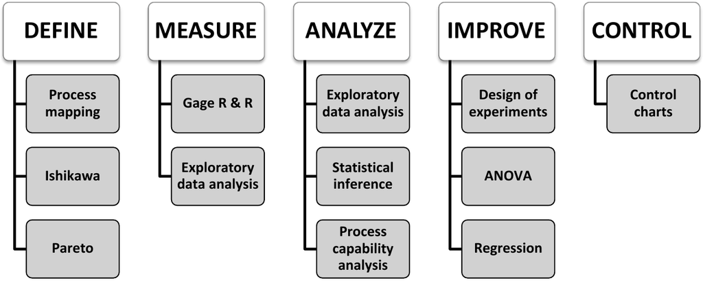

Figure 1: Statistical tools applied in each steps of the Six Sigma methodology.

The use of different SQC techniques was standardized With the development of the Six Sigma method by Motorola in 1997 (Pande et al. 2000). Six Sigma is a methodology or even philosophy focused on variability reduction that promotes the use of statistical methods and tools in order to improve processes in industry and services. The Six Sigma application is composed of five stages: Define, Measure, Analyze, Improve, and Control (DEMAIC). Figure 1 shows some representative statistical techniques applied in each of the Six Sigma stages. The two most representative statistical tools of SQC are the control charts and the process capability analysis (Montgomery 2009). Therefore, the proposed [*qcr*](https://CRAN.R-project.org/package=qcr) package has been developed in order to provide users a comprehensive and free set of programming tools to apply control charts and perform capability analysis in the SQC framework.  
The control stage is characterized by the use of tools based on anomaly detection and correction (Montgomery 2009). The most representative techniques of this stage and the primary tool of the Statistical Process Control (SPC) are the control charts (Champ and Woodall 1987). They have been developed to evaluate the process performance and at any time. The use of control charts prevents the process from getting out of control, and helping to detect the assignable causes corresponding to variations of the critical-to-quality features (CTQs), thus performing process changes when actually required. Furthermore, control charts provide estimates of the natural range of process variation (natural control limits), allowing us to compare this range with those limits specified by standards, company managers, or customers (specification limits). Hence, the process monitoring can be carried out by comparing each new observation with these natural limits, preventing defects in the final product. Briefly, a control chart is a two-dimensional graph whose axis represents the variable or attribute that is being monitored (CTQ variables). The estimation of natural control limits of the CTQ variables is developed by a process composed of two phases: In Phase I, the natural control limits are estimated using a preliminary sample (calibration sample) where we assume that the causes of variation are only random. In Phase II, each new observation is plotted on the control chart along with the natural limits obtained in the previous step. The set of new observations (twhich are not used to calculate the natural control limits) make up the so-called monitoring sample. Patterns, observations of out of control limits, runs of more than six observations on one side of the central line, among others, are some of the different criteria to identify out of control states in a specific process, providing also valuable information about the detection of any assignable causes of variation in the monitoring.

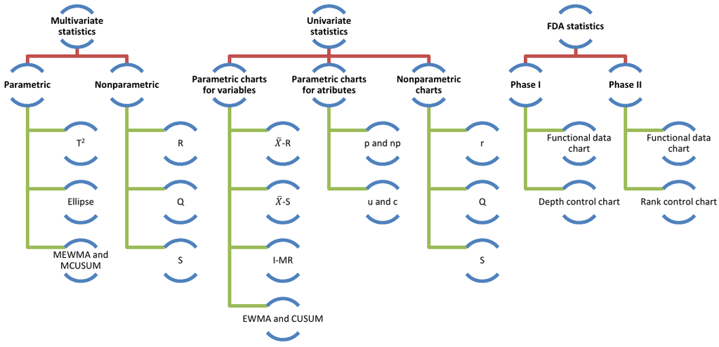

Figure 2: Control charts implemented in the [*qcr*](https://CRAN.R-project.org/package=qcr) package.

The most used control charts are based on the assumptions of normality and independence of the studied CTQ variables. These charts are used to control the position and dispersion of CTQ attributes and variables. Figure 2 shows some of the most important types of control charts. These can be classified according to the type of feature that is being controlled (attribute or variable), the variable dimension (univariate or multivariate), and assuming or not a parametric distribution of the variable (parametric or nonparametric). The [*qcr*](https://CRAN.R-project.org/package=qcr) package provides charts for the mean ($\bar{x}$), standard deviation ($s$), range ($R$), individual measurements ($I$), moving ranges ($MR$), proportion of nonconforming units ($p$), number of nonconforming units ($np$), number of defects per unit ($c$), mean number of defects per control unit ($u$), exponentially weighted moving average (EWMA), and cumulative sum control chart (CUSUM). The last two techniques are also called memory control charts, and they are specially designed to detect shifts of less than two standard deviations, both when using rational samples or individual measurements. On the other hand, new control charts based on the concept of data depth and developed by (Liu 1995) are implemented in [*qcr*](https://CRAN.R-project.org/package=qcr). Those are the $r$, $Q$, and $S$ control charts, the nonparametric alternatives for individual measurements, mean control chart, and CUSUM control chart, respectively. When more than one variable defines the process quality, multivariate control charts are applied. If the Gaussian assumption is met, the Hotelling T$^2$ control chart can be applied. If we want to detect small deviations, multivariate EWMA (MEWMA) and multivariate CUSUM (MCUSUM) can be implemented. When no parametric distribution is assumed, $r$, $Q$, and $S$ charts can be used.  
Another interesting SQC tool, which is very useful in the industry, is the Process Capability Analysis (PCA). It estimates how well a process meets the tolerances defined by the company, customers, standards, etc., by comparing the specification tolerances with respect to the natural range of variation of CTQ features. The capability of the process is measured using capability indicators. Process Capability Ratio (PCR) is a numerical score that helps the manufacturers know whether the output of a process meets the engineering specifications. Large PCR values show that the industrial or service process is capable of meeting the customer requirements. There have been many different PCRs developed in the last four decades that require the Gaussian assumption for the CTQ variable (Boyles 1991). However, many processes in industry and real applications do not meet this hypothesis. Thus, we could innacuratelly estimate the capability using PCR. Hence, many authors have studied different nonparametric alternatives to traditional PCR (Polansky 2007).  
The [*qcr*](https://CRAN.R-project.org/package=qcr) package has been developed in R (R Core Team 2021) under the GNU license. Nowadays, there are other R packages that currently provide quality control tools for users. The use of each one is shown in Figure 3.  
The [*qcc*](https://CRAN.R-project.org/package=qcc) package (Scrucca 2004) was developed by Professor Luca Scrucca of the Department of Economics, Finance, and Statistics at the University of Perugia. It enables us to perform Shewhart quality control charts for variables and attributes, as well as the CUSUM and EWMA charts for detecting small changes in the CTQ variable. Multivariate analysis is performed applying the Hotelling T$^2$ control chart. Additionally, it has functions implemented to obtain the operating characteristic curves (OC) and to estimate process capability analysis indices. Pareto and Ishikawa diagrams are also implemented. Otherwise, the [*IQCC*](https://CRAN.R-project.org/package=IQCC) package (Barros 2017) is maintained by Professor Emanuel P. Barbosa of the Institute of Mathematics in the State University of Campinas. It has a smaller number of control charts implemented, but it incorporates multivariate graphics. The *qualityTools* package (Roth 2016) was developed to aid learning in quality sciences. Figure 3 shows some of its utilities, e.g., capability analysis (providing a comprehensive set of parametric distributions) and design of experiments. In addition, the [*SixSigma*](https://CRAN.R-project.org/package=SixSigma) library (Cano et al. 2012, 2015) provides alternative functions to *qualityTools* and [*qcc*](https://CRAN.R-project.org/package=qcc) packages and the possibility of implementing process maps.

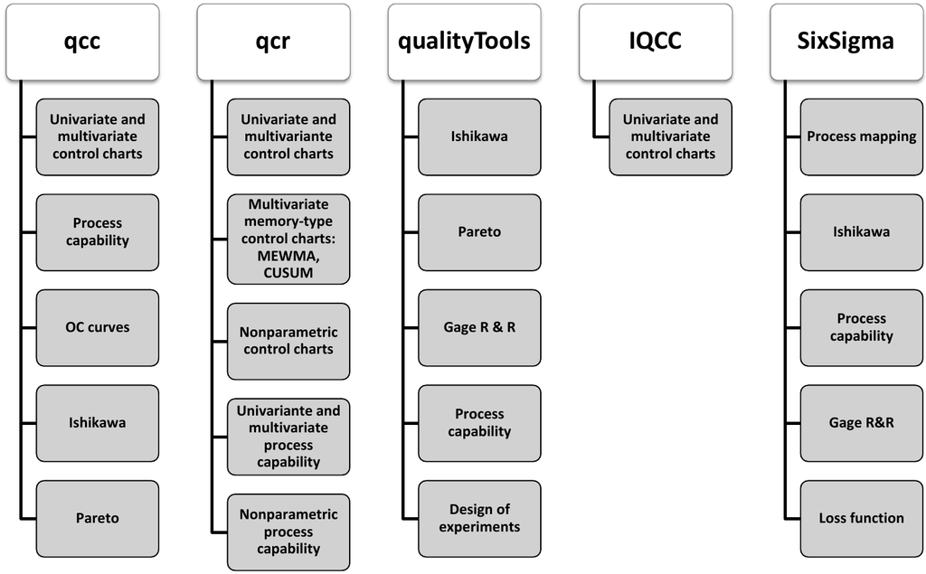

Figure 3: Comparison between the main packages in R devoted to Statistical Quality Control and the [*qcr*](https://CRAN.R-project.org/package=qcr) package.

Furthermore, there are other libraries specifically focused on control chart applications. Namely, the [*spcadjust*](https://CRAN.R-project.org/package=spcadjust) (Gandy and Kvaloy 2013) that allows us to estimate the calibration control limits of Shewhart, CUSUM, and EWMA control charts, and the [*spc*](https://CRAN.R-project.org/package=spc) (Knoth 2021) which provides tools for the evaluation of EWMA, CUSUM, and Shiryaev-Roberts control charts by using Average Run Length and RL quantiles criteria. Moreover, the [*MSQC*](https://CRAN.R-project.org/package=MSQC) package (Santos-Fernandez 2013) is a set of tools for multivariate process control, mainly control charts. It contains the main alternatives for multivariate control charts such as Hotelling (T$^2$), Chi-squared, MEWMA, MCUSUM, and Generalized Variance control charts. It also includes some tools to evaluate the multivariate normal assumption. The corresponding multivariate capability analysis can be performed using the [*MPCI*](https://CRAN.R-project.org/package=MPCI) library (Santos-Fernández and Scagliarini 2012) that provides different multivariate capability indices. It is also interesting to mention the [*edcc*](https://CRAN.R-project.org/package=edcc) package (Zhu and Park 2013) for its economic design of control charts by minimizing the expected cost per hour of the studied process.

It is important to emphasize that the [*qcr*](https://CRAN.R-project.org/package=qcr) package also includes new applications such as nonparametric approaches of control charts and capability indices (also covering the capability plots), which are currently unavailable in the R software.

## 2 Datasets in the qcr package

The [*qcr*](https://CRAN.R-project.org/package=qcr) package contains new databases (see table 1) based on study cases tackled by the authors during their professional activity as well as well-known datasets implemented on other packages focused on statistical quality control such as:

- **archery1:** It consists of a stage in which the archer shoots 72 arrows. The information is given in x and y coordinates. It is implemented in the [*MSQC*](https://CRAN.R-project.org/package=MSQC) package (Santos-Fernandez (2013)).
- **circuit:** Number of nonconformities observed in 26 successive samples of 100 printed circuit boards. It is implemented in the [*qcc*](https://CRAN.R-project.org/package=qcc) package (Scrucca (2004)).
- **dowel1:** Diameter and length of a dowel pin. It is implemented in the [*MSQC*](https://CRAN.R-project.org/package=MSQC) package (Santos-Fernandez (2013)).
- **orangejuice:** Frozen concentrated orange juice is packed in 6-oz cartons. These cartons are formed on a machine by spinning them from a cardboard stock and attaching a metal bottom panel. A can is then inspected to determine whether, when filled, the liquid could possibly leak either on the side seam or around the bottom joint. If this occurs, a can is considered nonconforming. The data were collected as 30 samples of 50 cans each at half-hour intervals over a three-shift period in which the machine was in continuous operation. It is implemented in the [*qcc*](https://CRAN.R-project.org/package=qcc) package (Scrucca (2004)).
- **pcmanufact:** A personal computer manufacturer counts the number of nonconformities per unit on the final assembly line. He collects data on 20 samples of 5 computers each. It is implemented in the [*qcc*](https://CRAN.R-project.org/package=qcc) package (Scrucca (2004)).
- **pistonrings:** Piston rings for an automotive engine are produced by a forging process. The inside diameter of the rings manufactured by the process is measured on 25 samples, each of size 5, drawn from a process being considered ‘in control’. It is implemented in the [*qcc*](https://CRAN.R-project.org/package=qcc) package (Scrucca (2004)).

Table 1: Some of the specific datasets included in the [*qcr*](https://CRAN.R-project.org/package=qcr) package

| **Name** | **Description** |
| --- | --- |
| **counters** | A water supply company wants to control the performance of the water counters installed throughout a city. For this purpose, 60 rational samples have been taken, each one composed by 3 measurements, f… |
| **employment** | A Spaniard-Argentinian hotel company wants to control the level of occupancy (measured in %) in their establishments through the application of a continuous control. For this purpose, 48 subsamples ha… |
| **oxidation** | This database contains information about the resistance against the oxidation of olive oil of the Picual variety. Five measurements of the Onset Oxidation Temperature (OOT, index that measures the res… |
| **plates** | A chemical company is developing a patent for a new variant of artificial stone mostly made of quartz (93wt% and polyester resin). This company is launching a pilot plant where it begins to produce pl… |
| **presion** | A shipyard of recreational boats is intended to optimize and control the mechanical properties of the yacht hulls made of a composite based on epoxy resin. In this regard, the modulus of elasticity du… |

## 3 Univariate and multivariate parametric control charts in qcr

The construction of a control chart is equivalent to the plotting of the acceptance regions of a sequence of hypothesis tests over time. Namely, the $\bar{x}$ chart is a control chart used to monitor the process mean $\mu$. It plots the sample means, $\bar{X}$’s, corresponding to subgroups of the $\{X_1,X_2,...\}$ observations and is equivalent to test the hypotheses $H_0:\mu=\mu_0$ versus $H_{\alpha}:\mu \neq \mu_0$ (for some target value $\mu_0$) conducted over time, using $\bar{x}$ as the test statistic. Here we assume that $\{X_1,X_2,...\}$ are the sample measurements of a particular CTQ feature that follows the $F$ distribution with mean $\mu$ and standard deviation $\sigma$. When there is insufficient evidence to reject $H_0$, we can state that the process is under control; otherwise, the process is out of control. In other words, processes are under control when their sources of variation are only the sources common to the process (Brown and Wetherill 1990). The decision to reject or not $H_0$ is based on the value of the sample mean $\bar{x}$ observed at each time interval (Liu and Tang 1996). The control charts are easy to construct, visualize, and interpret, and most important, have proven their effectiveness in practice since the 1920’s.

Control charts are defined, on the one hand, by a center line that represents the average value of the CTQ feature corresponding to the in-control state and, on the other hand, two horizontal lines, called the upper control limit (UCL) and the lower control limit (LCL). The region between the control limits corresponds to the region where $H_0$ is not rejected (defined in the previous section). As a consequence, the process will be out of control when an observed rational sample or an individual measurement falls outside the limits. Let $w$ be a sample statistic that measures a quality characteristic of interest, and suppose that the mean of $w$ is $\mu_w$ and the standard deviation of $w$ is $\sigma_w$. Then the center line, the upper control limit, and the lower control limit become:
$$UCL=\mu_w + L \sigma_w$$

$$CL=\mu_w$$

$$LCL=\mu_w - L \sigma_w,$$
where $L$ is the “distance” of the control limits from the center line, expressed in standard deviation units.

Table 2: Univariate Shewhart, multivariate Hotelling T$^2$, univariate and multivariate CUSUM and EWMA and FDA control charts available in the [*qcr*](https://CRAN.R-project.org/package=qcr) package

|  |  | **Statistical quality control charts for** |
| --- | --- | --- |
| **Function** | **Chart name** | **Variables** |
| `qcs.xbar` | $\bar{X}$ | Sample means of a continuous process variable are plotted to control the process average. |
| `qcs.R` | $R$ | Sample ranges of a continuous process variable are plotted to control the process variability. |
| `qcs.S` | $S$ | Sample standard deviations of a continuous variable are plotted to control the process variability. |
| `qcs.one` | $I$ | Sample values from a I chart data of a continuous process variable to control the level (position) of the process. |
|  |  | **Attributes** |
| `qcs.p` | $p$ | Proportion of nonconforming units is plotted, the number of defective items follow a binomial distribution. |
| `qcs.np` | $np$ | Number of nonconforming units is plotted, and the chart is constructed based on the average of the process. |
| `qcs.c` | $c$ | Nonconformities per unit are plotted, number of defects in a large population follow a Poisson distribution. |
| `qcs.u` | $u$ | Average nonconformities per unit are plotted, this chart does not require a constant number of units. |
| `qcs.g` | $g$ | Number of non-events between events are plotted, it counts the number of events between rarely-occurring errors or nonconforming incidents. |
|  |  | **Attributes and variables** |
| `qcs.cusum` | CUSUM | Cumulative sums for individual observations or for the averages of rational subgroups are plotted to monitor the process mean. |
| `qcs.ewma` | EWMA | The exponential weighed average of CTQ variables are plotted to identify small changes in the process (measured as rational samples or individual observations). |
|  |  | **Multivariate control charts** |
| `mqcs.t2` | T$^2$ | Multivariante Hotelling T$^2$ control chart for individual observations (vectors). |
| `mqcs.mcusum` | MCUSUM | Multivariate Cumulative Sum control chart for individual observations (vectors). |
| `mqcs.ewma` | MEWMA | Multivariate EWMA control chart for individual observations (vectors). |
|  |  | **Functional data control charts** |
| `fdqcs.depth` | Phase I | Phase I control chart for functional data: depth control chart and deepest curves envelope. |
| `fdqcs.rank` | Phase II | Phase II control chart for functional data: rank control chart and deepest curves envelope. |
| `plot.fdqcs` | FDA plots | Graphical outputs for Phase I and Phase II control charts for functional data. |

When several random variables characterize the quality of a process/service, applying statistical multivariate quality control techniques becomes necessary. In fact, if we analyze each variable separately, the probability that an observation of a variable will fall within the calculated limits when it is known that the process is actually under control will no longer be 0.9973 for $6\sigma$ amplitude. Assuming independence, it will be $0.9973^p$, where $p$ is the number of CTQ features, while the probability of type I will actually lead to $\alpha'=1-(1-\alpha)^p$. Therefore, the control limits are different from those drawn, assuming the control of each CTQ variable independently from the others. Moreover, if the variables are dependent, the calculation of $\alpha$ becomes more complex. This subject is particularly important today, as automatic inspection procedures make it customary to measure many parameters of each product over time. The more common multivariate parametric control charts are the Hotelling T$^2$ (to identify big shifts) and the multivariate CUSUM (MCUSUM) and EWMA (MEWMA) for identifying small shifts.

The functions that compute the quality control statistics for the different univariate control charts (involving continuous, attribute or count data) are shown in Table 2. For the sake of simplicity and taking into account that these types of control charts are implemented in other packages, the use of these functions is not shown in this work. More details are given in the help of [*qcr*](https://CRAN.R-project.org/package=qcr) package (Flores et al. 2021).

## 4 Nonparametric control charts based on data depth

The control charts presented in this section were proposed by (Liu 1995) as an alternative to those described in previous section. The main idea of its control graphs is to reduce each multivariate measure to the univariate index, that is, its relative center-exterior classification induced by a depth of data. This approach is completely nonparametric, and therefore, these control charts are not defined by any parametric assumption regarding the process model. Thus, they are applicable in a wider number of case studies than those counterparts such as $T^2$, MCUSUM, and MEWMA control charts. In addition, these graphs allow the simultaneous detection of the change of location (shift of the mean) and the increase of the scale (change in variability) in a process.

(Liu 1995) proposed and justified three types of control charts, the $r$, $Q$, and $S$ charts which can be considered as data-depth-based multivariate generalizations of the univariate $X$, $\bar{x}$, and CUSUM charts, respectively.

### 4.1 Data depth

In multivariate analysis, the term depth refers to the degree of centrality of a point regarding a data cloud or a probability distribution. Therefore, it is possible to define a rank in the multidimensional Euclidean space through the calculation of observation depth. According to (Dyckerhoff 2004) and Cascos et al. (2011), the depth function can be defined as a bounded function $D_{p}:R^{d} \longrightarrow R$, with $P$ the distribution set in $R^d$, that assigns at each point of $R^d$ its degree of centrality with respect to $P$. Depth functions with which control charts can be performed are the

- Simplicial depth (Liu (1990)),
- Mahalanobis depth (Mahalanobis (1936)),
- Halfspace or Tukey depth (Tukey (1975)),
- Likelihood depth (Fraiman et al. (1997)), and
- Random projection depth (Zuo and Serfling (2000)).

### 4.2 Statistics derived from data depth

Let $G$ a $k$-dimensional distribution, and let $Y_1,\dots,Y_m$ be $m$ random observations from $G$. The sample $Y_1, \dots , Y_m$ is generally the reference sample of a CTQ variable in the context of quality control, composed of measurements from products obtained by an under control process. If $X_1, X_2, \dots$ are the new observations from the manufacturing process, assuming that the different $X_i$ values follow an $F$ distribution if the quality of the studied product has been deteriorated or, in other words, if the process is out of control. Otherwise, they follow a $G$ distribution. Let $D_G(\cdot)$ denote a notion of depth, and assume that $G$ and $F$ are two continuous distributions. Thus, if all the $D_G(Y_i)$ values are sorted in increasing order, and $Y_{[j]}$ denotes the sample value associated with the $j$th smallest depth value, then $Y_{\left[ 1\right]},\ldots,Y_{\left[ m\right]}$ are the order statistics of $Y_i$’s, with $Y_{[m]}$ being the most central point. Therefore, the smaller the order (or the rank) of a point, the farther that point will be from the underlying distribution $G(\cdot)$.

Liu (1995) defines the rank statistic as
$$r_{G}\left( y\right)= P\left\lbrace D_{G}\left( Y\right) \leq D_{G}\left( y\right) \mid Y\sim G \right\rbrace$$
whereby $Y \sim G$ indicates that the random variable $Y$ follows the distribution $G$. When $G$ is unknown, the empirical distribution $G_{m}$ of the sample $\{Y_1, \ldots, Y_m\}$ can be used instead, and the statistic is defined by
$$r_{G_{m}}\left( y\right)= \frac{ \# \left\lbrace D_{G_{m}}\left( Y_j\right) \leq D_{G_{m}}\left( y\right), j = 1,\ldots,m \right\rbrace}{m}$$
In the same way that $r_{G}$ and $r_{G_{m}}$, the $Q$ statistics can be also defined as follows

$$Q\left( G,F\right)= P\left\lbrace D_{G}\left( Y\right) \leq D_{G}\left( X\right) \mid Y\sim G, X\sim F \right\rbrace=E_{F}\left[ r_{G}\left( X\right) \right]$$

$$Q\left( G,F_{n}\right)= \frac{1}{n} \sum _{i=1}^{n} r_{G}\left( X_i\right)$$

$$Q\left( G_{m},F_{n}\right)= \frac{1}{n} \sum _{i=1}^{n} r_{G_{m}}\left( X_i\right),$$

whereby $F_n(\cdot)$ denotes the empirical distribution of the sample $\{X_1, \dots , X_n\}$. The control charts corresponding to these statistics can be developed as described in the following sections.

### 4.3 The $r$ chart

Calculate $\left\lbrace r_{G}\left( X_1\right),r_{G}\left( X_2\right),\ldots,r_{G}\left( X_n\right)\right\rbrace$ or $\left\lbrace r_{G_{m}}\left( X_1\right),r_{G_{m}}\left( X_2\right),\ldots,r_{G_{m}}\left( X_n\right)\right\rbrace$ if $G$ is unknown but $Y_1,\ldots,Y_m$ are available. As a result, the $r$ chart consists of plotting the rank statistic in regard to time. The control chart central line is CL = $0.5$, whereas the lower limit is LCL =$\alpha$, with $\alpha$ accounting for the false alarm rate. The process will be out of control if $r_G(\cdot)$ falls under LCL. A small value of the rank statistic $r_{Gm}(X)$ means that only a very small proportion of $Y_i$ values are more outlying than $X$. Therefore, assuming that $X \sim F$, then a small value of $r_{Gm}(X)$ suggests a possible deviation from $G$ to $F$. This may be due to a shifting in the location and/or an increase in the scale of the studied CTQ variable. Taking into account that the UCL is not defined for the $r$ chart, the CL line serves as a reference to identify emerging patterns, runs, or trends. If $r_{Gm}(X)$ is greater than 0.5, there is evidence of scale decreasing, and also could take place a negligible location shift. This case should be tackled as an improvement in quality given a gain in the accuracy, and thus the process should not be considered as out of control.

### 4.4 The $Q$ chart

The idea behind the $Q$ chart is similar to the one behind the $\bar{x}$ chart. If $X_1, X_2, \dots$ are univariate and $G$ is a normal distribution, the $\bar{x}$ chart plots the averages of consecutive subsets of the different $X_i$. A goal of this type of chart is that it can prevent the identification of a false alarm when the process is actually in control (even when some individual sample points fall out of control limits due to random fluctuations).  
The $Q$ chart is the nonparametric alternative to the $\bar{x}$ chart. It is performed by plotting the averages of consecutive subsets of size $n$ corresponding to the rank statistic ($r_G(X_i)$ or $r_{Gm}(X_i)$), given by $Q\left( G,F_{n}^j\right)$ or $Q\left( G_{m},F_{n}^j\right)$, whereas $F_n^j$ is the empirical distribution of the $X_i$’s in the $j$th subset, $j =1, 2, \dots$. Accordingly, if only $\left\lbrace Y_1, Y_2,\ldots, Y_m \right\rbrace$ are available, the $Q$ chart plots the sequence $\left\lbrace Q\left( G_{m},F_{n}^j\right),Q\left( G_{m},F_{n}^j\right),\ldots\right\rbrace$.  
Depending on the value of $n$, the corresponding control limits are as follows:

- If $n \geq 5$, $CL = 0.5$ and
  - $LCL = 0.5-Z_{\alpha}\left( 12n\right)^{\frac{1}{2}}$ for $Q\left( G,F_{n}^j\right)$.
  - $LCL = 0.5-Z_{\alpha}\sqrt{\frac{1}{12}\left(\frac{1}{m}+\frac{1}{n}\right)}$ for $Q\left( G_m,F_{n}^j\right)$.
- If $n < 5$, $CL = 0.5$ and $LCL = \frac{\left( n!\alpha\right)^{\frac{1}{n}}}{n}$.

### 4.5 The $S$ control chart

The $S$ control chart is based on the CUSUM univariate control chart, which is basically the plot of $\sum_{i=1}^{n}\left( X - \mu \right)$, which reflects the pattern of the total deviation from the expected value. As mentioned above, it is more effective than the $X$ chart or the $\bar{x}$ chart in detecting small process changes. The nonparametric CUSUM chart based on data depth suggests plotting $S_n(G)$ and $S_n(G_m)$, defined by
$$S_n\left( G\right) = \sum_{i=1}^{n}\left( r_G\left( X_i\right) - \frac{1}{2} \right)$$
with control limits $CL = 0$ and $LCL = -Z_{\alpha}\left(\frac{n}{12}\right)^{\frac{1}{2}}$ and
$$S_n\left( G_m\right) = \sum_{i=1}^{n}\left( r_{G_{m}}\left( X_i\right) - \frac{1}{2} \right).$$
If only $Y_1, \dots Y_m$ are available, the control limits are $CL = 0$ and $LCL = -Z_{\alpha}\sqrt{n^2\frac{\left(\frac{1}{m}+\frac{1}{n}\right)}{12}}$. The LCL control limits in both cases constitute a curve instead of a straight line; if $n$ is large, the control chart $S$ should be standardized as follows:
$$S_n^{*}\left( G\right) = \frac{S_n^{*}\left(G\right)}{\sqrt{\frac{n}{12}}}$$

$$S_n^{*}\left( G_m\right) = \frac{S_n\left(G_m\right)}{\sqrt{n^2\frac{\left(\frac{1}{m}+\frac{1}{n}\right)}{12}}}$$
Therefore, this $S^*$ chart is defined by $CL = 0$ and $LCL = -Z_{\alpha}$.

### 4.6 Examples of $r$, $Q$ and $S$ control charts applied using synthetic data

A bivariate data set is used to illustrate how the previously discussed control charts arise. In fact, a synthetic dataset composed of 540 observations of a bidimensional standard Gaussian variable has been simulated, in addition to 40 individuals corresponding to another bidimensional Gaussian variable with mean and standard deviation equal to 2.

```r
R> mu <- c(0, 0)
R> Sigma <- matrix(c(1, 0, 0, 1), nrow = 2)
R> Y <- rmvnorm(540, mean = mu, sigma = Sigma)
R> u <- c(2, 2)
R> S <- matrix(c(4, 0, 0, 4), nrow = 2)
R> x <- rmvnorm(40, mean = u, sigma = S)
```

Prior to the application of nonparametric control charts, the dataset has to be converted into a `npqcsd` object. The synthetic dataset is arranged as two matrices, `G` composed of the 500 first rows (multivariate observations) of `Y`, and `x` with the remaining ones and including those belonging to the second bidimensional variable

```r
R> x <- rbind(Y[501:540, ], x)
R> G <- Y[1:500, ]
R> data.npqcd <- npqcd(x, G)
```

In the same way, the `npqcd` function creates a data object for non parametric quality control, the `npqcs.r()`, `npqcs.Q()`, and `npqcs.S()` functions computes all the statistics required to obtain the $r$, $Q$, and $S$ control charts, respectively. The argument `method = c("Tukey", "Liu", "Mahalanobis", "RP", "LD")` specifies the data depth function, and `alpha` is the signification level that defines the LCL. See (Flores et al. 2021) to obtain additional information about these functions and their arguments.

#### $r$ chart

The $r$ control chart can be obtained by applying the `npqcs.r()` function to the `npqcd` object and plotting the result.

```r
R> res.npqcs <- npqcs.r(data.npqcd, method = "Tukey", alpha = 0.025)
R> plot(res.npqcs, title = " r Control Chart")
```

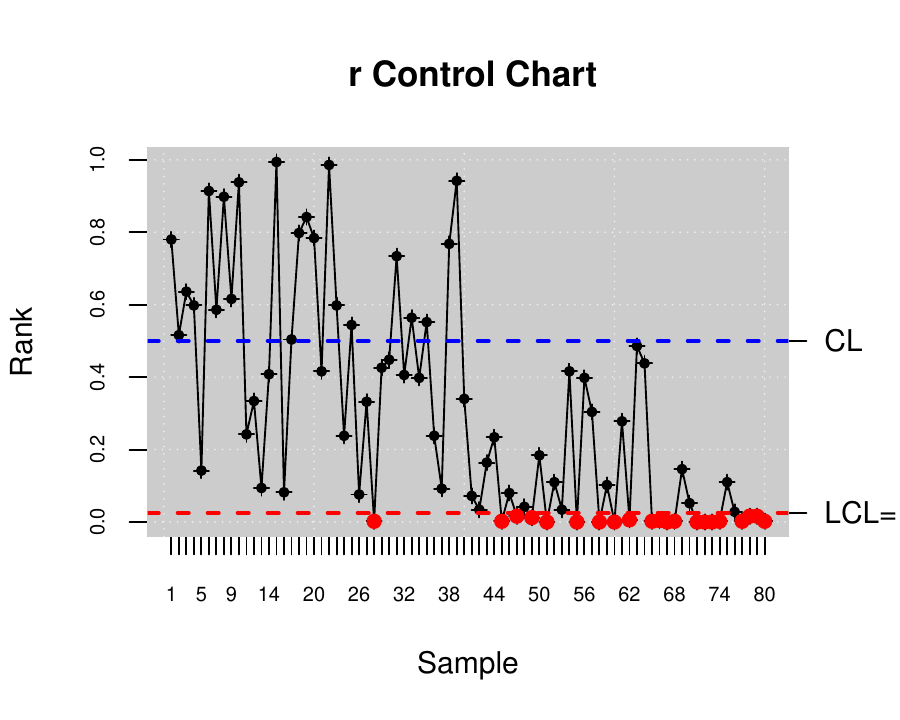

Figure 4: $r$ control chart.

#### $Q$ chart

In this case, the dataset is assumed to be composed of rational samples of size 4. Thus, the $Q$ nonparametric alternative of $\bar{x}$ chart is proposed and applied to control the bidimensional process:

```r
R> n <- 4    # samples
R> m <- 20   # measurements
R> k <- 2    # number of variables
R> x.a <- array( , dim = c(n, k, m))
R> for (i in 1:m) {
+      x.a[, , i] <- x[(1 + (i - 1) * n):(i * n), ]
+  }
R> data.npqcd <- npqcd(x.a, G)
R> res.npqcs <- npqcs.Q(data.npqcd, method = "Tukey", alpha = 0.025)
R> plot(res.npqcs, title = "Q Control Chart")
```

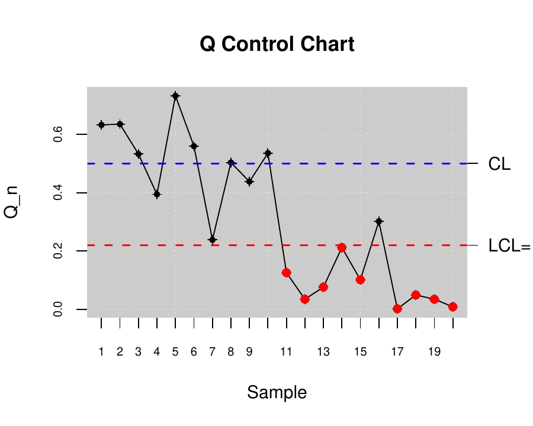

Figure 5: $Q$ control chart.

#### $S$ chart

Finally, the nonparametric counterpart of CUSUM control chart is performed from the multivariate individual observations.

```r
R> data.npqcd <- npqcd(x, G)
R> res.npqcs <- npqcs.S(data.npqcd, method = "Tukey", alpha = 0.05)
R> plot(res.npqcs, title = "S Control Chart")
```

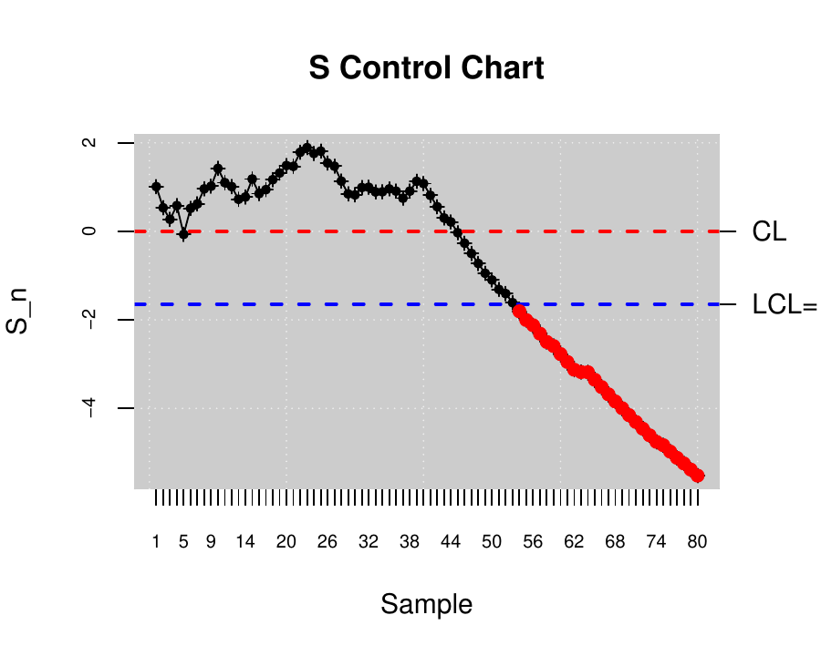

Figure 6: $S$ control chart.

### 4.7 Control charts for functional data based on data depth

In the paradigm of Industry 4.0, processes and services are many times described by continuously monitored data of hourly, daily, monthly curves or smooth functions. When the processes are defined by functional data, the authors encourage to apply control charts based on Functional Data Analysis (FDA) in order to implement control and improvement tasks. In this section, the use of control charts presented in Flores et al. (Flores et al. 2020). Summarizing, this methodology consists of the proposal of new Phase I and Phase II control charts to be applied in those case study in which the datum unit is a curve. Phase I control chart is based on the computation of functional data depth (specifically Fraiman and Muniz (Fraiman and Muniz 2001), Mode (Cuevas et al. 2007), and random projections (Cuevas et al. 2007) data depth) from which a data depth control chart is developed. Once the in-control calibration sample is obtained, the Phase II control chart based on functional data depth and rank nonparametric control chart can be applied. In addition to the Phase I functional data depth and Phase II rank control charts, plots of functional envelopes from the original curves are provided in order to help to identify the possible assignable causes of out of control states.

#### Estimating a Phase I control chart for functional data (calibration)

A dataset is simulated in order to illustrate the use of FDA control charts for Phase I and II. A functional mean, $mu_0$, and a functional standard deviation, `sigma`, are defined as shown in (Flores et al. 2020). An $n_0=100$ hundred curves composed of $m=30$ points are simulated. They account for the calibration or retrospective sample.

```r
R> library(fda.usc)
R> m <- 30
R> tt<-seq(0,1,len=m)
# H0
R> mu_0<-30 * tt * (1 - tt)^(3/2)
R> n0 <- 100
R> mdata<-matrix(NA,ncol=m,nrow=n0)
R> sigma <- exp(-3*as.matrix(dist(tt))/0.9)
R> for (i in 1:n0) mdata[i,]<- mu_0+0.5*mvrnorm(mu = mu_0,Sigma = sigma )
```

Prior to the application of control charts, the dataset is converted in a specific format by the `fdqcd` function. A plot function is also programmed to properly show the original functional data, `plot.fdqcd`. Figure 7 shows the original functional data consisting of curves.

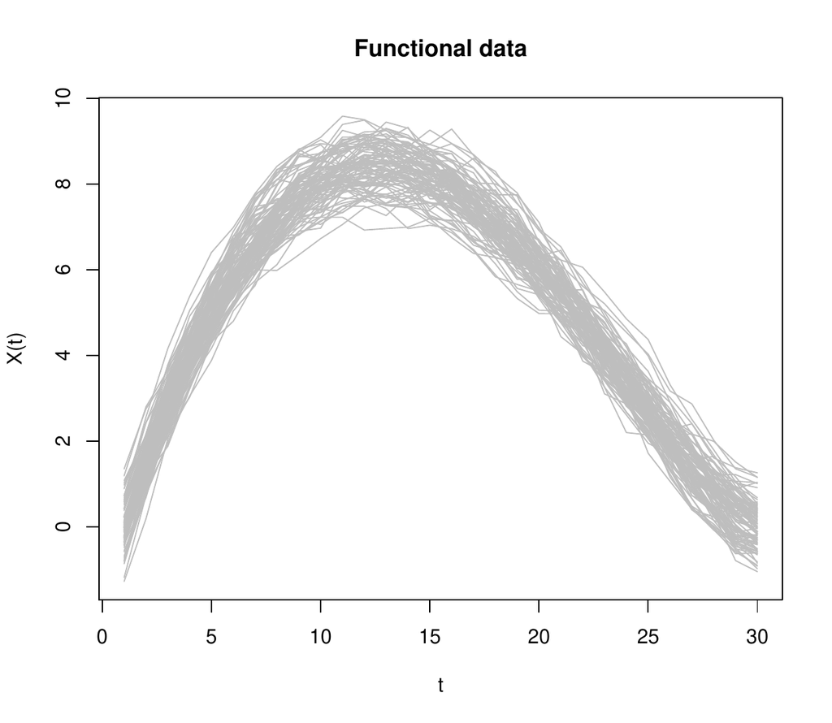

Figure 7: Original curves that account for the calibration sample.

```r
R> fdchart <- fdqcd(mdata)
R> plot(fdchart,type="l",col="gray",main="Functional data")
```

The following step is to identify those curves that account for the in-control process. This task is done by the application of a Phase I control chart for functional data. This method is implemented in the [*qcr*](https://CRAN.R-project.org/package=qcr) package by the `fdqcs.depth` function. Specifically, the arguments and default values for these functions are

```r
R> fdqcs.depth.default <- function(x, data.name=NULL,func.depth = depth.mode,nb=200,
+                                 type = c("trim","pond"),ns =  0.01,
+                                 plot = TRUE, trim = 0.025, smo =0.05,
+                                 draw.control = NULL,...)
```

where `func.depth` is the type of depth measure, by default `depth.mode`, `nb` the number of bootstrap resamples, `type` accounts for the method used to trim the data, `trim` or `pond` (Flores et al. 2020), `ns` is the quantile to determine the cutoff from the bootstrap procedure (Flores et al. 2020), `plot` a logical value indicating that it should be plotted, `trim` the percentage of the trimming, `smo` the smoothing parameter for the bootstrap resampling (Flores et al. 2020), whereas `draw.control` specifies the `col`, `lty`, and `lwd` for the fdataobj, statistic, IN and OUT objects. When the `fdqcs.depth` function is applied to the curves of the calibration sample, the `fddep` object of `fdqcs.depth` class is obtained. It is composed of the original data, the depth corresponding to each curve, the lower control limit of the depth chart, the index of those curves out of control, the curves that account for the limits of the envelope composed by the deepest cures, and the deepest curve or functional median.

```r
R> fddep <- fdqcs.depth(fdchart)
R> summary(fddep)
```

```r
      Length Class  Mode
fdata 100    fdata  list
Depth 100    -none- numeric
LCL     1    -none- numeric
out     1    -none- numeric
fmin    1    fdata  list
fmax    1    fdata  list
fmed    1    fdata  list
ns      1    -none- numeric
```

```r
R> class(fddep)
```

```r
[1] "fdqcs.depth"
```

```r
R> plot(fddep,title.fdata = "FDA chart",title.depth = "Depth chart")
R> out <- fddep$out; out
```

```r
[1] 29
```

Figure 8 shows the control chart for the depth of the curves (right panel). The LCL is estimated by a smoothed bootstrap procedure (Flores et al. 2020). In order to provide a tool to identify the assignable cause of each out-of-control curve, the original curves with the envelope with the 99% of the deepest curves are also shown (left panel). The analysis of the shape and magnitude of the curves in and out of bounds can help to associate each curve out of control to an assignable cause, allowing for processes control, maintenance, and improvement.

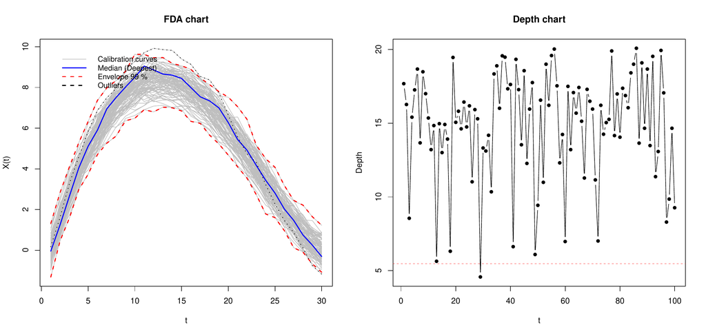

Phase I ends when a calibration sample without curves out of control is obtained. The iterative procedure to obtain an in control calibration sample is shown in the following lines.

```r
R> alpha <- 0.1
R> trim <- 0.1
R> while (length(out)>0) {
R>   mdata <- fddep$fdata$data[-out,]
R>   fddep <- fdqcs.depth(mdata,ns = alpha, trim=trim, plot=FALSE)
R>   out <- fddep$out
R> }
R> plot(fddep,title.fdata = "Envelope with the 90\% deepest curves",
+  title.depth = "Depth control chart")
```

Figure 9 is obtained from the application of `plot` function to `fddep` object. It shows that all the curves of the calibration sample are in control, and thus, the natural variability of the process is estimated.

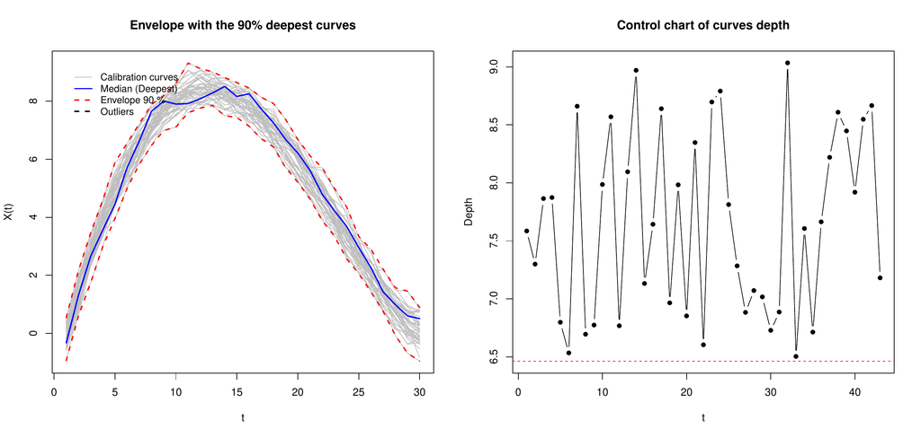

Figure 9: Results corresponding to the second iteration to obtain the in control calibration sample. Left panel: Original curves with the envelope composed of the 90% of the deepest curves. Right panel: Control chart for the depths of the curves (the LCL has been estimated by bootstrap procedures at a signification level of 10%.

#### Estimating a Phase II control chart for functional data (monitoring)

The next step is to perform the Phase II of process control. The monitoring phase is performed by the application of Phase II control charts for functional data based on multivariate nonparametric control charts. Firstly, a monitoring sample composed of 50 curves is simulated by the following code.

```r
R> mu_a<- 30 * tt^(3/2) * (1 - tt)
R> n_a <- 50
R> mdata_a<-matrix(NA,ncol=m,nrow=n_a)
R> for (i in 1:n_a) mdata_a[i,]<- mu_a+0.5*mvrnorm(mu = mu_a,Sigma = sigma )
```

The curves of the monitoring sample are defined with `fdqcd` format and a control chart for Phase II is developed by applying the `fdqcs.rank` function. It is composed by the following arguments, `fdqcs.rank(x, y = x, func.depth = depth.FM, alpha = 0.01, plot = TRUE,` `trim = 0.1, draw.control = NULL,...)`.

```r
R> fdchart_a <- fdqcd(mdata_a,"Monitoring curves")
R> phase2.chart <- fdqcs.rank(fdchart,fdchart_a)
R> plot(phase2.chart)
R> summary(phase2.chart)
```

Figure 10 accounts for the FDA chart with the calibration sample and its envelope composed by the deepest curves. Moreover, the monitoring sample is also included and compared with the calibration sample by using the FDA chart. In addition, the Phase II rank control chart for functional data is shown including both calibration and monitoring samples or only the ranks corresponding to the monitoring sample. The second population that corresponds with the monitoring sample is identified by the control chart from the first monitored curve (panels below in Figure 10).

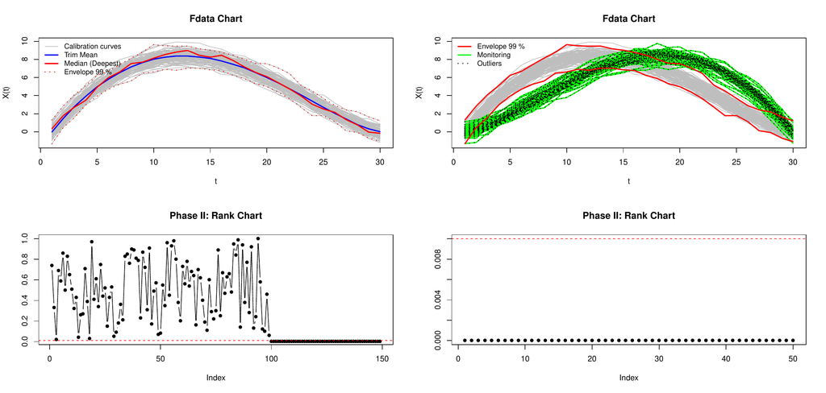

Figure 10: First row: the left and right panels show the FDA charts for the calibrating and monitoring samples with a signification level of 0.01. Second row: The left and right panels show the Phase II rank control chart for functional data, including calibration and monitoring sample (left panel) and only monitoring sample (right panel).

## 5 Process capability analysis

The analysis of the capability of a process in the case of statistical quality control is done through the calculation of the so-called capability. These indices measure whether a process is capable or not of meeting the corresponding technical specifications set by the customer, or the manufacturer, by comparing those with the natural variability of the CTQ variable that characterizes the process. The interpretation of these indices is associated with the result of this relation. Capability indices are generally calculated as the ratio between the length of the specification interval and the natural variability of the process in terms of $\sigma$. Large values of these indices mean that the corresponding process is capable of producing articles that meet the requirements of the client and manufacturers. In other words, the larger the value of the capability index, the smaller the number of products outside the specification limits.

In this section, we describe the capability indices for processes whose underlying distribution is normal and not normal (exponential, Weibull, etc.). However, it is important to note that the development of programming tools for nonparametric capability analysis is one of the main goals and contributions of the [*qcr*](https://CRAN.R-project.org/package=qcr) package. In addition to the estimation of capability indices, a graphical output is provided. Based on the proposal of *qualityTools* package, the [*qcr*](https://CRAN.R-project.org/package=qcr) graphical output for capability analysis includes a normality test for the CTQ variable, a Q-Q plot, a histogram with the theoretical Gaussian distribution density, parametric and nonparametric estimates of capability indices and a contour capability control chart. In the following lines, parametric and nonparametric capability analysis utilities are described using different examples of applications.

### 5.1 Assuming a normal distribution

The most widely used capability indexes in the industry analyze the process capability under the assumptions of a stabilized process (in control) and a Gaussian distributed CTQ variable. Table 3 shows the main parametric (assuming Gaussian distribution) indices, namely $C_p$, $C_{pk}$, $C_{pm}$, and $C_{pmk}$.

Vännman (1995) proposed a general formulation of these indices by an expression that depends on the non-negative parameters $u$ and $v$:
$$C_p\left( u,v\right)= \frac{d-u\vert \mu - m\vert}{3\sqrt{\sigma^2+v\left( \mu - T\right)^2}},$$
whereby $d=(USL-LSL)/2$, $m=(LSL+USL)/2$, $USL$ is the upper specification limit, the $LSL$ is the lower specification limit, $\sigma$ is the theoretical standard deviation, $\mu$ accounts for the theoretical mean of the CTQ variable, and $T$ is the specification target (by default the mean between the $LSL$ and $USL$). The indices shown in Table 3 are obtained from this expression just considering values of 0 or 1 for $u$ and $v$: $C_p\left( 0, 0\right) = C_p$, $C_p\left( 1, 0\right) = C_{pk}$, $C_p\left( 0, 1\right) = C_{pm}$, $C_p\left( 1, 1\right) = C_{pmk}$.

Table 3: PCR from first to fourth generation, $USL$ is the upper specification limit, $LSL$ is the lower specification limit, $\mu$ is the real mean, $\hat{\mu}$ is the estimated mean, and $\hat{\sigma}$ is the estimated standard deviation.

[output not shown]

```r
R> data("pistonrings")
R> xbar <- qcs.xbar(pistonrings[1:125, ], plot = FALSE)
R> limits <- c(lsl = 73.99, usl = 74.01)
R> # qcs.cp(object = xbar, parameters = c(0, 0), limits = limits,
R> #        contour = FALSE)
R> # qcs.cp(object = xbar, parameters = c(1, 0), limits = limits,
R> #        contour = FALSE)
R> # qcs.cp(object = xbar, parameters = c(0, 1), limits = limits,
R> #        contour = FALSE)
R> qcs.cp(object = xbar, parameters = c(1, 1), limits = limits,
+         contour = FALSE)
```

```r
     Cpmk delta.usl gamma.usl
   0.2984    0.1176    0.9785
```

Consequently, the obtained results are $C_p=0.3407$, $C_{pk}=0.3006$, $C_{pm}=0.3382$, and $C_{pmk}=0.2984$, respectively. The argument `parameters` account for $u$ and $v$ values, while `object` is the type of control chart from which the $\sigma$ is estimated, `limits` are the specification control limits, and `contour` is the parameter that indicates when the process capability contour chart is plotted.

### 5.2 Process capability plot

In Vännman (2001) and Deleryd and Vännman (1999), a graphical method (based on common capability indices) to analyze the capability of a process is proposed. The goal of using this type of plot (if compared with respect to only capability indices calculation) is to provide immediate information of the location and spread of the CTQ feature and about the capability to meet the specifications of the corresponding process. When using this chart, a process will be $capable$ if the process capability index is higher than a certain value $k$, with $k> 1$. The most used values for $k$ are $k = 1$, $k = 4/3$, or $k = 5/3$, even 2 at a Six Sigma level, taking into account the usual index limits for which a process could be assumed capable. It will also be assumed that the target value matches the center of the specification interval, that is, $T = \frac{\left( USL + LSL\right)}{2} = m$. Then, one of the indices defined by the $C_p\left( u,v\right)$ family is used, e.g., $C_{pk}$ or $C_{pm}$, and the process will be defined as capable if $C_p\left( u, v \right)> k$, given the values of $u$, $v$, and $k$. Also note that if $\mu = T$, all the $C_p\left( u, v\right)$ indices are defined by the same expression as the $C_p$. Moreover, different setting for $u$, $v$, and $k$ impose different constraints on the process parameters $\left( \mu, \sigma \right)$. This can be easily seen through a process capability plot. This graph is a contour plot of $C_p\left( u, v\right) = k$ as a function of $\mu$ and $\sigma$, but it can also be defined as a function of $\delta$ and $\gamma$, with $\delta = \frac{\mu - T}{d}$ and $\gamma = \frac{\sigma}{d}$. The contour line is obtained by rewriting the index $C_p\left( u,v\right)$ as a function of $\delta$ and $\gamma$ as follows $C_p\left( u,v\right)= \frac{1-u\vert \delta \vert}{3\sqrt{\gamma^2+v\left( \delta \right)^2}}$. Therefore, the $C_p\left( u,v\right) = k$ equation is solved, plotting $\gamma$ depending on the values of $\delta$. The resulting expressions are:
$$\gamma = \sqrt{\frac{\left( 1-u\vert\delta\vert\right)}{9k^2}-v\delta^2}, \; \vert\delta\vert \leq \frac{1}{u+3k\sqrt{v}}, \; \left( u,v\right) \neq \left(0,0 \right)$$
When $u = v = 0$, that is, when we consider the index $C_p=k$, we have $\gamma = \frac{1}{3k}$ and $\vert\delta\vert \leq 1$. It is important to highlight that the $\gamma$-axis accounts for the process spread, whereas the $\delta$-axis accounts for the process location. The values of the parameters $\mu$ and $\sigma$ which provide values $\left( \delta,\gamma\right)$ within the region bounded by the contour line $C_p\left(u, v\right) = k$ and the $\delta$-axis will provide a larger $C_p\left(u, v\right)$ value than $k$, leading a capable process. Furthermore, values of $\mu$ and $\sigma$ which provide values $\left( \delta,\gamma\right)$ outside this region will provide a value $C_p\left(u, v\right)$ smaller than $k$, i.e., a non-capable process. In the case of the process not being capable, this type of plot is useful to understand if the corrective actions have to be performed to decrease the process spread, or the process location (deviation with respect to target), or even when both changes are needed to improve the process capability. This can be observed by observing the distance with respect to the $x$ and $y$-axis. Below are some examples of capability plot application which can be generated through the application of the `qcs.cp` function with `contour=TRUE` and `k=1` (default values):

```r
R> oldpar <- par(mfrow = c(2, 2))
R> qcs.cp(object = xbar, parameters = c(0, 0), limits = limits,
+         ylim = c(0, 1))
R> qcs.cp(object = xbar, parameters = c(1, 0), limits = limits,
+         ylim = c(0, 1))
R> qcs.cp(object = xbar, parameters = c(0, 1), limits = limits,
+         ylim = c(0, 1))
R> qcs.cp(object = xbar, parameters = c(1, 1), limits = limits,
+         ylim = c(0, 1))
R> par(oldpar)
```

The result is shown in Figure 11. In all the cases, the points in red are out of the area defined by the line in blue and the $\delta$ axis. Thus, the corresponding process is not capable, no matter the capability index that is used. In any case, note that the $C_{p}$ index is useless in identifying non-capable processes due to location shifts with respect to the target. In the same way, the $C_{pk}$ index assumes as capable processes that are far from the target as long as they were close to the specification limits (as shown in Figure 11). Thus, the use of the $C_{pm}$ and $C_{pmk}$ are recommended due to they take into account both shifts from the target and the spread. In the present case, the process is not capable due to the spread rather than the target shift. Therefore, the process changes could be due to decreases in the variability process.

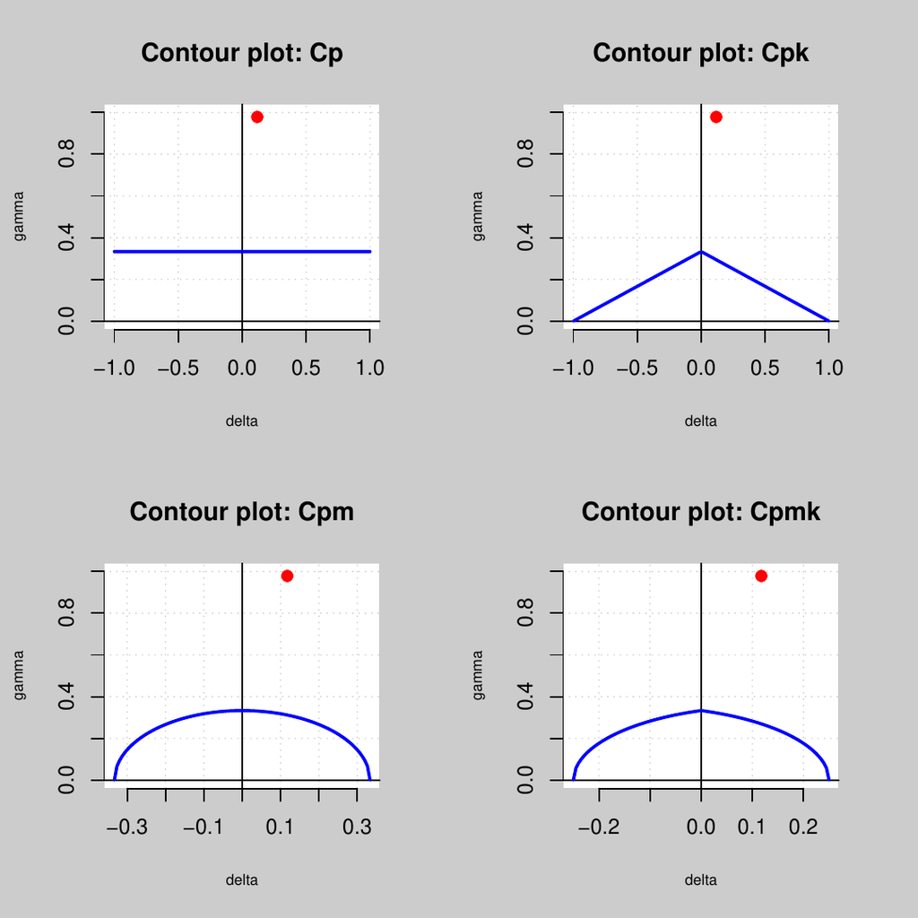

Figure 11: Process capability plots using the $C_p$, $C_{pk}$, $C_{pm}$, and $C_{pmk}$ indexes.

### 5.3 Estimated process capability plot

In practice, the process parameters are unknown and we need to estimate them. We can perform a decision rule based on the sample statistics that provide a sample estimate of the capability index and, finally the so called estimated process capability plot, also called $\gamma^*-\delta^*$ plot (Deleryd and Vännman 1999). It allows us to decide whether a process is capable or not assuming that $\mu$ and $\sigma$ parameters are unknown and estimated by $\hat{\mu}=\bar{X}$ and $\hat{\sigma}^2=\frac{1}{n}\sum_{i=1}^n{X^2_i-\bar{X}^2}$. They are the maximum likelihood estimators when the CTQ variable of the process is normally distributed, and $X_1,X_2,\dots,X_n$ is a random sample of a normal distribution with $\mu$ mean and $\sigma^2$ variance.
The [*qcr*](https://CRAN.R-project.org/package=qcr) package only provides the $\gamma^*-\delta^*$ plot corresponding to the $C_{pm}$ index taking into account that the other capability indices do not consider shifts from the target value in their calculations. For the general case, see the work of (Vännman 2001). In order to obtain an appropriate decision rule for the case of $C_{pm}$ index, we test the hypotheses $H_0 : C_{pm} \leq k_0$ versus $H_1 : C_{pm} > k_0$, using
$$\hat{C}_{pm}= \frac{d}{3\sqrt{\hat{\sigma}^2+\left( \hat{\mu} - T\right)^2}}$$
as test statistic. The null hypothesis will be rejected if $\hat{C}_{pm} > c_{\alpha}$, where the constant $c_{\alpha}$ is determined by previously defining a signifition test level $\alpha$ . Vännman (2001) showed that the null hypothesis $H_0:C_{pm} \leq k_0$ can be reduced to $H_0:C_{pm}=k_0$. Thus, for given values of $\alpha$ and $n$, the process will be considered capable if $\hat{C}_{pm} > c_{\alpha}$, with $c_{\alpha} > k_0$. Hubele and Vannman (2004) proved that, when the $C_{pm}$ index is used, the critical value for a given $\alpha$ is obtained as
$$c_{\alpha}=k_0\sqrt{\frac{n}{\chi^2_{\alpha,n}}},$$
where $\chi^2_{\alpha,n}$ is the quantile $\alpha$ of a $\chi^2$ distribution with $n$ degrees of freedom. The [*qcr*](https://CRAN.R-project.org/package=qcr) package includes the `qcs.hat.cpm()` function to obtain both the theoretical capability plot and the estimated capability plot from sample statistics. Among other options, the user can indicate the control chart from which the estimates $\hat{\mu}$ and $\hat{\sigma}$ are obtained (alternatively, $\hat{\mu}$ and $\hat{\sigma}$ can be introduced through `mu` and `std.dev`), and the specification limits using `limits`. Furthermore, the signification level and the capability limit can be modified, as they are set to $\alpha=0.05$ and $k_0=1$ by default. The following code illustrates its application to `pistonrings` data.

```r
R> xbar <- qcs.xbar(pistonrings[1:125, ], plot = FALSE)
R> limits <- c(lsl = 73.99, usl = 74.01)
R> # qcs.hat.cpm(object = xbar, limits = limits, ylim = c(0,1))
R> mu <- xbar$center
R> std.dev <- xbar$std.dev
R> qcs.hat.cpm(limits = limits, mu = mu, std.dev = std.dev, ylim = c(0,1))
```

The result is shown in Figure 12. The contour line corresponding to the capability region obtained from the capability index sample is always more restrictive than the corresponding theoretical one.

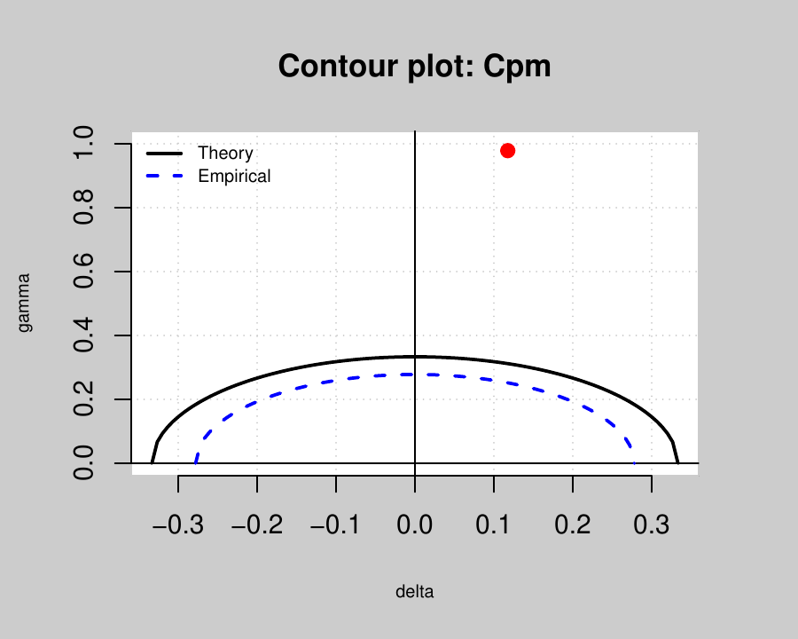

Figure 12: Comparison between theorical and estimated process capability plots.

### 5.4 Nonparametric capability analysis

Traditional assumptions about data such as normality or independence are frequently violated in many real situations. Thus, in scenarios in which assumptions of normality are not verified, the indices defined in the previous sections are not valid. Pearn and Chen (1997) and Tong and Chen (1998) proposed generalizations of $C_p\left(u, v\right)$ for the case of arbitrary distributions of data
$$C_{Np}\left( u,v\right)= \frac{d-u\vert M - m\vert}{3\sqrt{\left(\frac{F_{99.865}-F_{0.135}}{6} \right)^2+v\left( M - T\right)^2}},$$
where $F_{\alpha}$ is the percentile $\alpha$% of the corresponding distribution and $M$ the median of the process. However, the distribution of the underlying process is always unknown. (Chang and Lu 1994) calculated estimates for $F_{99.865}$, $F_{0.135}$ and $M$ based on the sample percentiles.

Pearn and Chen (1997) proposed the following estimator
$$\hat{C}_{Np}\left( u,v\right)= \frac{d-u\vert \hat{M} - m\vert}{3\sqrt{\left(\frac{U_p-L_p}{6} \right)^2+v\left( \hat{M} - T\right)^2}}$$
where $U_p$ is an estimator for $F_{99.865}$, $L_p$ is an estimator for $F_{0.135}$, and $\hat{M}$ is an estimator for $M$, obtained from the tables developed by (Gruska et al. 1989).

The `qcs.cpn()` function of [*qcr*](https://CRAN.R-project.org/package=qcr) calculates $C_{Np}$, $C_{Npk}$, $C_{Npm}$, and $C_{Npmk}$ using the formulation described by Tong and Chen (1998). The code that illustrates its use is shown below. To obtain the nonparametric capability indices it is necessary to indicate the $u$ and $v$ parameters.

```r
R> xbar <- qcs.xbar(pistonrings[1:125, ], plot = FALSE)
R> limits <- c(lsl = 73.99, usl = 74.01)
R> # x <- xbar$statistics[[1]]
R> # median <- median(x)
R> # q = quantile(x, probs = c(0.00135, 0.99865)) # c(lq, uq)
R> # qcs.cpn(parameters = c(0, 0), limits = limits, median = median, q = q)
R> # qcs.cpn(object = xbar, parameters = c(0, 0), limits = limits)
R> # qcs.cpn(object = xbar, parameters = c(1, 0), limits = limits)
R> # qcs.cpn(object = xbar, parameters = c(0, 1), limits = limits)
R> qcs.cpn(object = xbar, parameters = c(1, 1), limits = limits)
```

```r
 CNpmk
0.9015
```

Thus, the values obtained are $C_{Np}=1.0082$, $C_{Npk}=0.9275$, $C_{Npm}=0.9799$ and $C_{Npmk}=0.9015$. If a capability limit of $k=1$ or $k=1.33$ is assumed, we can infer that the process is not actually capable to meet the customers or manager’s requirements.

### 5.5 Tools for a comprehensive processs capability analysis

Function `qcs.ca()` provides a comprehensive information of the capability of a process, summarized through a graphical output. This function calculates the process capability indices $C_p$, $C_{pk}$, $C_{pL}$, $C_{pU}$, $C_{pm}$, $C_{pmk}$ from a `qcs` object, assuming a Gaussian distribution. Moreover, it computes confidence limits for $C_p$ using the method described by Chou et al. (1990). Approximate confidence limits for $C_{pl}$, $C_{pu}$, and $C_{pk}$ are also estimated using the method described in Bissell (1990), while the confidence limits for $C_{pm}$ are based on the approximated method of Boyles (1991) that assumes the target is the mean of the specification limits. Moreover, the $C_{Np}$, $C_{Npk}$, $C_{Npm}$, and $C_{Npmk}$ nonparametric capability indices are also obtained. There is also a specific box within the summary plot that shows the proportion of observations and expected observations under the Gaussian assumption out of the specification limits (nonconforming observations). Further, a histogram of the data sample is provided, in addition to the corresponding Gaussian density curves obtained from the sample estimates (one per standard deviation estimate procedure). They are displayed along with the specification limits, a quantile-quantile plot for the specified distribution, and a process capability plot obtained from the $C_{pm}$ index (both using theoretical and sample alternatives). In order to describe the `qcs.ca()` performance, the following code corresponds to the analysis of the first 125 observations of the `pistonrings` dataset (the corresponding output is shown in Figure 13).

```r
R> qcs.ca(xbar, limits = c(lsl = 73.99, usl = 74.01))
```

```r
Process Capability Analysis

Call:
qcs.ca(object = xbar, limits = c(lsl = 73.99, usl = 74.01))

Number of obs = 125          Target = 74
       Center =  74               LSL =  73.99
       StdDev =  0.009785         USL =  74.01

Paremetric Capability indices:

       Value    0.1%   99.9%
Cp    0.3407  0.2771  0.4065
Cp_l  0.3807  0.2739  0.4875
Cp_u  0.3006  0.2021  0.3991
Cp_k  0.3006  0.1944  0.4068
Cpm   0.3382  0.2749  0.4038


Non parametric Capability indices:

        Value
CNp    1.0082
CNpK   0.9275
CNpm   0.9799
CNpmk  0.9015


PPM:

         Exp<LSL 1.267e+07       Obs<LSL 0
         Exp>USL 1.836e+07       Obs>USL 8e+05
       Exp Total 3.103e+07     Obs Total 8e+05

Test:


    Anderson Darling Test for normal distribution

data:  xbar
A = 0.1399, mean = 74.001, sd = 0.005, p-value = 0.9694
alternative hypothesis: true distribution is not equal to normal
```

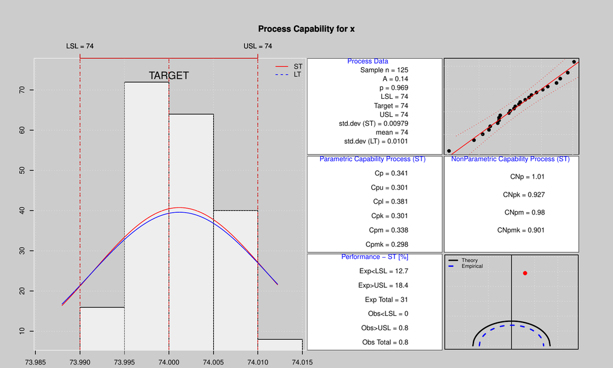

Figure 13: A complete analysis of the process capability.

## 6 Conclusions

The [*qcr*](https://CRAN.R-project.org/package=qcr) package has been developed to provide users with a comprehensive set of functions that manage statistical process control, ranging from univariate parametric analysis to multivariate and FDA nonparametric statistics. This package includes the main types of control charts and capability indices. It combines the main features of reputed SQC packages in R such as [*qcc*](https://CRAN.R-project.org/package=qcc) and *qualityTools* with the proposal of a new graphical appearance and the implementation of new SQC tools with increasing importance in Industry 4.0 such as multivariate and nonparametric analysis.  
In addition to some utilities provided by reference R packages such as [*qcc*](https://CRAN.R-project.org/package=qcc), [*SixSigma*](https://CRAN.R-project.org/package=SixSigma), and *qualityTools*, [*qcr*](https://CRAN.R-project.org/package=qcr) implements very important statistical techniques of Control and Analysis tasks of the Six Sigma procedure that are not included in other libraries. In the case of multivariate control charts, these tools are the MEWMA and MCUSUM multivariate control charts, on the one hand, and the $r$, $Q$ and $S$ nonparametric control charts based on data depth, on the other hand. In addition, Phase I and Phase II control charts for functional data (monthly, daily, hourly curves) based on functional data depth, bootstrap procedures, and nonparametric rank charts have also been implemented in the [*qcr*](https://CRAN.R-project.org/package=qcr) package. These control charts for functional data provide tools to control and improve processes when their CTQ variables are obtained as hourly, monthly, daily, yearly smooth curves.  
It is also very important to note that [*qcr*](https://CRAN.R-project.org/package=qcr) provides functions to perform nonparametric capability analysis. In addition, the new implementation of the process capability plots for the main parametric capability indices allows us to analyze if improvements in process spread or/and process location are needed to obtain a capable process. The comparison between suppliers, machines, etc., is enabled through capability plots.  
All these utilities intend to make [*qcr*](https://CRAN.R-project.org/package=qcr) a useful tool for users of a wide variety of industries, providing a competitive alternative to commercial software.

## Acknowledgments

The work of Salvador Naya, Javier Tarrío-Saavedra, Miguel Flores and Rubén Fernández-Casal has been supported by MINECO grant MTM2017-82724-R, and by the Xunta de Galicia (Grupos de Referencia Competitiva ED431C-2020-14 and Centro de Investigación del Sistema universitario de Galicia ED431G 2019/01), all of them through the ERDF. The research of Miguel Flores has been partially supported by Grant PII-DM-002-2016 of Escuela Politécnica Nacional of Ecuador. In addition, the research of Javier Tarrío-Saavedra has been also founded by the eCOAR project (PC18/03) of CITIC. The authors thank Mateo Larco and Bibiana Santiso for their valuable help with the English edition.

### 6.1 Supplementary materials

Supplementary materials are available in addition to this article. It can be downloaded at RJ-2021-034.zip

### 6.2 CRAN packages used

qcr, qcc, MSQC, IQCC, SixSigma, spcadjust, spc, MPCI, edcc

### 6.3 CRAN Task Views implied by cited packages

F. Barros. *IQCC: Improved quality control charts.* 2017. URL https://CRAN.R-project.org/package=IQCC. R package version 0.7.

A. Bissell. How reliable is your capability index? *Applied Statistics*, 331–340, 1990.

R. A. Boyles. The Taguchi capability index. *Journal of Quality Technology*, 23: 17–26, 1991.

D. W. Brown and G. B. Wetherill. *Statistical process control.* Chapman; Hall, 1990.

E. L. Cano, J. M. Moguerza and M. P. Corcoba. *Quality control with R.* New York: Springer-Verlag, 2015.

E. L. Cano, J. M. Moguerza and A. Redchuk. *Six Sigma with R.* New York: Springer-Verlag, 2012.

I. Cascos, A. López and J. Romo. Data depth in multivariate statistics. *Boletı́n de Estadı́stica e Investigación Operativa*, 27(3): 151–174, 2011.

C. W. Champ and W. H. Woodall. Exact results for Shewhart control charts with supplementary runs rules. *Technometrics*, 29(4): 393–399, 1987.

P.-L. Chang and K.-H. Lu. PCI calculations for any shape of distribution with percentile. *Quality World Technical Supplement*, 110–114, 1994.

Y.-M. Chou, D. Owen and S. Borrego A. Lower confidence limits on process capability indices. *Journal of Quality Technology*, 22(3): 223–229, 1990.

A. Cuevas, M. Febrero and R. Fraiman. Robust estimation and classification for functional data via projection-based depth notions. *Computational Statistics*, 22(3): 481–496, 2007.

M. Deleryd and K. Vännman. Process capability plots a quality improvement tool. *Quality and Reliability Engineering International*, 15(3): 213–227, 1999.

R. Dyckerhoff. Data depths satisfying the projection property. *Allgemeines Statistisches Archiv*, 88(2): 163–190, 2004.

M. Flores, R. Fernández–Casal, S. Naya and J. Tarrío–Saavedra. *Qcr: Quality control review.* 2021. URL https://CRAN.R-project.org/package=qcr. R package version 1.3.

M. Flores, S. Naya, R. Fernández-Casal, S. Zaragoza, P. Raña and J. Tarrı́o-Saavedra. Constructing a control chart using functional data. *Mathematics*, 8(1): 58, 2020.

R. Fraiman, R. Y. Liu and J. Meloche. Multivariate density estimation by probing depth. *Lecture Notes-Monograph Series*, 415–430, 1997.

R. Fraiman and G. Muniz. Trimmed means for functional data. *Test*, 10(2): 419–440, 2001.

A. Gandy and J. T. Kvaloy. Guaranteed conditional performance of control charts via bootstrap methods. *Scandinavian Journal of Statistics*, 40: 647–668, 2013. DOI 10.1002/sjos.12006.

G. Gruska, K. Mirkhani and L. Lamberson. Non normal data analysis. *St. Clair Shores, MI: Applied Computer Solutions, Inc*, 1989.

N. F. Hubele and K. Vannman. The effect of pooled and un-pooled variance estimators on $C_{pm}$ sub when using subsamples. *Journal of quality technology*, 36(2): 207, 2004.

S. Knoth. *Spc: Statistical process control – calculation of ARL and other control chart performance measures.* 2021. URL https://CRAN.R-project.org/package=spc. R package version 0.6.5.

R. Liu. On a notion of data depth based on random simplices. *The Annals of Statistics*, 18(1): 405–414, 1990.

R. Y. Liu. Control charts for multivariate processes. *Journal of the American Statistical Association*, 90(432): 1380–1387, 1995.

R. Y. Liu and J. Tang. Control charts for dependent and independent measurements based on bootstrap methods. *Journal of the American Statistical Association*, 91(436): 1694–1700, 1996.

P. C. Mahalanobis. On the generalised distance in statistics. *Proceedings of the National Institute of Sciences of India, 1936*, 49–55, 1936.

D. C. Montgomery. *Introduction to statistical quality control.* John Wiley & Sons (New York), 2009.

P. S. Pande, R. P. Neuman and R. R. Cavanagh. *The six sigma way: How GE, Motorola, and other top companies are honing their performance.* McGraw-Hill (New York), 2000.

W. Pearn and K. Chen. A practical implementation of the process capability index $C_{pk}$. *Quality Engineering*, 9(4): 721–737, 1997.

A. M. Polansky. Process capability indices, nonparametric. *Encyclopedia of Statistics in Quality and Reliability*, 2007.

R Core Team. *R: A language and environment for statistical computing.* Vienna, Austria: R Foundation for Statistical Computing, 2021. URL https://www.R-project.org/.

T. Roth. *qualityTools: Statistics in quality science.* 2016. URL http://www.r-qualitytools.org. R package version 1.55 http://www.r-qualitytools.org.

E. Santos-Fernandez. *Multivariate statistical quality control using R.* Springer-Verlag, 2013. URL http://www.springer.com/statistics/computational+statistics/book/978-1-4614-5452-6.

E. Santos-Fernández and M. Scagliarini. MPCI: An R package for computing multivariate process capability indices. *Journal of Statistical Software*, 47(7): 1–15, 2012. URL http://www.jstatsoft.org/v47/i07/.

L. Scrucca. qcc: An R package for quality control charting and statistical process control. *R News*, 4/1: 11–17, 2004. URL https://cran.r-project.org/doc/Rnews/.

L.-I. Tong and J.-P. Chen. Lower confidence limits of process capability indices for non-normal process distributions. *International Journal of Quality & Reliability Management*, 15(8/9): 907–919, 1998.

J. W. Tukey. Mathematics and the picturing of data. In *Proceedings of the international congress of mathematicians*, pages. 523–531 1975.

K. Vännman. A graphical method to control process capability. In *Frontiers in statistical quality control 6*, pages. 290–311 2001. Springer-Verlag.

K. Vännman. A unified approach to capability indices. *Statistica Sinica*, 805–820, 1995.

W. Zhu and C. Park. edcc: An R package for the economic design of the control chart. *Journal of Statistical Software*, 52(9): 1–24, 2013. URL http://www.jstatsoft.org/v52/i09/.

Y. Zuo and R. Serfling. General notions of statistical depth function. *Annals of statistics*, 461–482, 2000.